# Rede, Financiamento e Produção SUS em Mato Grosso do Sul

Matheus Assis de Oliveira

03/07/2026

# 1 Introdução

Este repositório é um **projeto R único** de análise aplicada sobre rede assistencial, financiamento municipal e produção do SUS em Mato Grosso do Sul. A proposta é organizar cinco dimensões analíticas em uma sequência única: estrutura da rede, orçamento, atenção primária, produção ambulatorial e perfis municipais integrados.

A pergunta central é: **como estrutura assistencial, financiamento e produção do SUS se distribuem entre os municípios, e quais perfis territoriais aparecem quando essas dimensões são analisadas em conjunto?**

# 2 Motivação

A análise isolada de bases públicas cria uma leitura fragmentada. CNES mostra capacidade instalada; SIOPS mostra financiamento; SISAB e SIA/SUS mostram produção; a análise de agrupamentos mostra perfis territoriais. Integrar essas dimensões torna a leitura mais útil para um perfil profissional de analista de dados: menos relatório solto, mais fluxo analítico reproduzível.

# 3 Dados

| Indicador | Resultado |
| --- | --- |
| Municípios analisados | 79 |
| População coberta | 2.901.895 |
| Estabelecimentos CNES | 6.529 |
| Leitos SUS | 4.618 |
| Equipamentos registrados | 42.143 |
| Produção ambulatorial aprovada | 55.366.170 |
| Valor ambulatorial aprovado | R$ 367.450.965 |
| Produção APS SISAB 2025 | 36.102.693 |
| Gasto em saúde per capita mediano | R$ 2.258 |
| Leitos SUS por 10 mil habitantes (mediana) | 13 |

Foram consolidados os seguintes blocos:

- **Rede assistencial**: estabelecimentos, leitos SUS, equipamentos e vínculo SUS.
- **Financiamento**: gasto per capita, composição do gasto e aplicação de recursos próprios.
- **Atenção primária**: produção municipal registrada no SISAB.
- **Produção ambulatorial**: quantidade e valor aprovado no SIA/SUS.
- **Perfil integrado**: agrupamento municipal por estrutura, gasto e indicadores de contexto.

# 4 Métodos

O projeto segue um fluxo simples:

1. consolidação das bases finais por município;
2. padronização de códigos municipais;
3. cálculo de indicadores por habitante e por 10 mil habitantes;
4. análise descritiva estadual;
5. rankings exploratórios;
6. análise de perfis municipais;
7. mapas coropléticos;
8. dashboard interativo.

# 5 Resultados descritivos

|  | indicador | media | mediana | minimo | maximo |
| --- | --- | --- | --- | --- | --- |
| population_2024 | population_2024 | 36732.85 | 14210.00 | 3620.00 | 954537.00 |
| facilities | facilities | 82.65 | 27.00 | 5.00 | 1418.00 |
| sus_beds | sus_beds | 58.46 | 18.00 | 0.00 | 1762.00 |
| existing_equipment | existing_equipment | 533.46 | 105.00 | 7.00 | 17273.00 |
| health_spending_per_capita | health_spending_per_capita | 2337.57 | 2258.00 | 891.54 | 4646.95 |
| outpatient_value_per_capita_brl | outpatient_value_per_capita_brl | 52.38 | 34.80 | 0.51 | 220.75 |
| primary_care_production_per_1000 | primary_care_production_per_1000 | 15922.59 | 15814.38 | 7621.19 | 26635.36 |

# 6 Análise exploratória

## 6.1 Perfis municipais integrados

| cluster | municipalities | population_2024 | median_population | facilities_per_10k | sus_beds_per_10k | equipment_per_10k | health_spending_per_capita | personnel_spending_share_health_spending | investment_share_health_spending | health_transfer_share_health_spending | own_revenue_applied_asps_lc141 | infant_mortality_rate | neonatal_mortality_rate | maternal_mortality_ratio | cluster_label |
| --- | --- | --- | --- | --- | --- | --- | --- | --- | --- | --- | --- | --- | --- | --- | --- |
| Cluster 1 | 9 | 48615 | 48615 | 24.26530 | 24.265301 | 86.02151 | 3497.800 | 45.26 | 3.340 | 21.680 | 19.35 | 14.705882 | 12.658228 | 0.0000 | Small municipalities with high local capacity |
| Cluster 2 | 6 | 53176 | 53176 | 14.21863 | 9.542458 | 45.15927 | 2464.665 | 39.80 | 13.085 | 48.865 | 20.89 | 28.370221 | 25.409373 | 613.4969 | High spending and outcome-alert profile |
| Cluster 3 | 31 | 2340839 | 2340839 | 27.91201 | 15.092776 | 107.38752 | 2007.480 | 49.32 | 2.690 | 43.430 | 23.11 | 14.814815 | 8.064516 | 0.0000 | Regional hubs and dense network |
| Cluster 4 | 33 | 459265 | 459265 | 16.95107 | 9.290541 | 60.04654 | 2152.770 | 48.43 | 3.500 | 32.050 | 23.86 | 9.925558 | 0.000000 | 0.0000 | Lower-density structure |

Os agrupamentos organizam os municípios em perfis úteis para leitura profissional: municípios pequenos com capacidade local elevada, perfis de maior gasto e alerta, polos regionais de rede mais densa e municípios com menor densidade estrutural.

## 6.2 Rankings

Maiores gastos em saúde per capita

|  | municipality_name | health_spending_per_capita | cluster_label |
| --- | --- | --- | --- |
| 39 | Inocência - MS | 4646.95 | Small municipalities with high local capacity |
| 46 | Jateí - MS | 4565.90 | Small municipalities with high local capacity |
| 76 | Taquarussu - MS | 4389.44 | Small municipalities with high local capacity |
| 70 | São Gabriel do Oeste - MS | 4270.45 | Regional hubs and dense network |
| 2 | Alcinópolis - MS | 4252.70 | Small municipalities with high local capacity |
| 63 | Porto Murtinho - MS | 3839.37 | Lower-density structure |
| 58 | Paraíso das Águas - MS | 3729.77 | Lower-density structure |
| 79 | Vicentina - MS | 3574.60 | High spending and outcome-alert profile |

Maiores valores ambulatoriais per capita

|  | municipality_name | outpatient_value_per_capita_brl | outpatient_approved_quantity |
| --- | --- | --- | --- |
| 20 | Campo Grande - MS | 220.75 | 31109887 |
| 69 | Santa Rita do Pardo - MS | 192.90 | 264190 |
| 28 | Coxim - MS | 168.54 | 808725 |
| 22 | Cassilândia - MS | 164.73 | 1450572 |
| 27 | Costa Rica - MS | 161.03 | 300604 |
| 59 | Paranaíba - MS | 144.52 | 1472667 |
| 9 | Aquidauana - MS | 140.04 | 1031696 |
| 78 | Três Lagoas - MS | 133.62 | 1774781 |

Maiores produções de APS por mil habitantes

|  | municipality_name | primary_care_production_per_1000 | primary_care_total_production_2025 |
| --- | --- | --- | --- |
| 46 | Jateí - MS | 26635.36 | 96420 |
| 29 | Deodápolis - MS | 25239.90 | 358659 |
| 21 | Caracol - MS | 24733.33 | 126511 |
| 13 | Batayporã - MS | 24132.29 | 264321 |
| 39 | Inocência - MS | 23815.77 | 207483 |
| 76 | Taquarussu - MS | 23595.44 | 88011 |
| 57 | Novo Horizonte do Sul - MS | 23102.47 | 111146 |
| 33 | Eldorado - MS | 22928.74 | 266730 |

# 7 Análise geoespacial

A análise geoespacial mostra a distribuição territorial dos indicadores. Ela é exploratória: mapas ajudam a localizar padrões, contrastes e hipóteses de investigação, mas não explicam causalidade sozinhos.

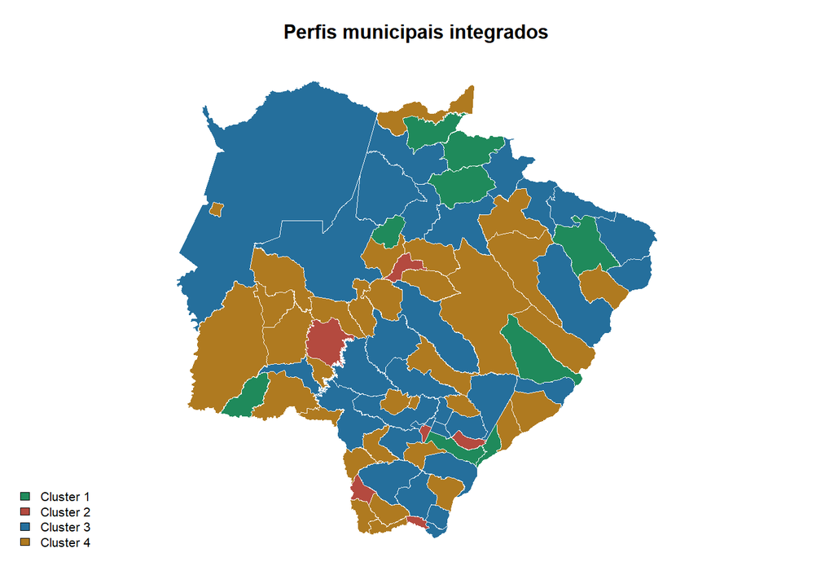

Perfis municipais integrados

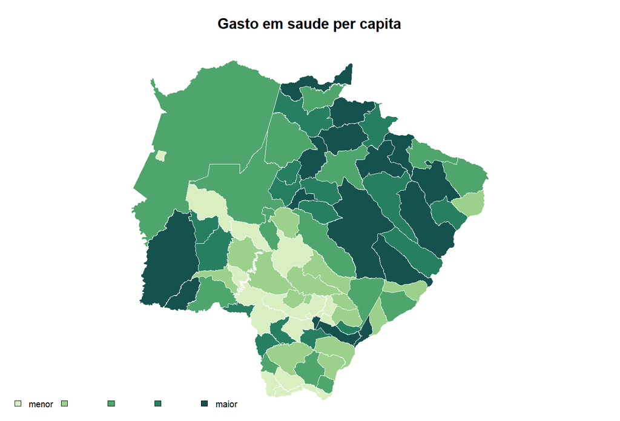

Gasto em saúde per capita

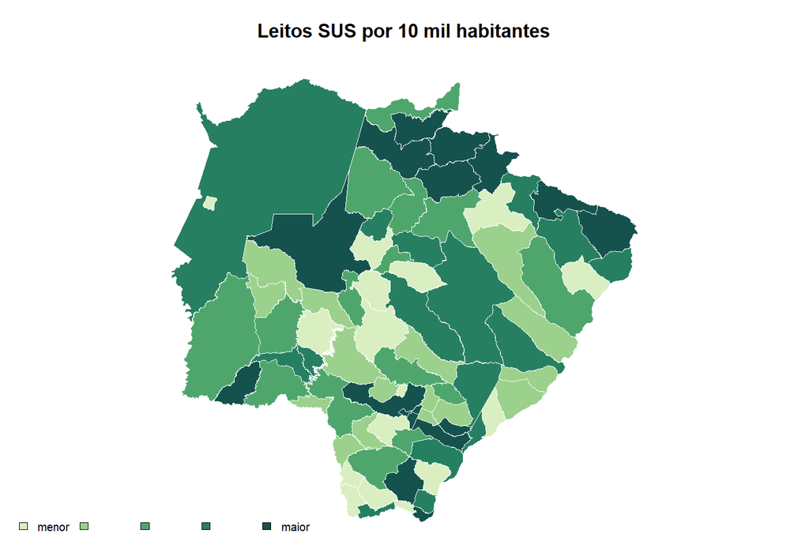

Leitos SUS por 10 mil habitantes

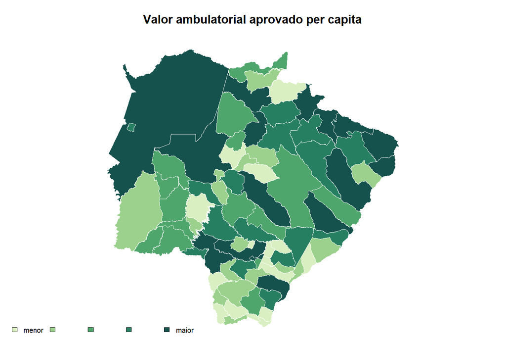

Valor ambulatorial aprovado per capita

# 8 Dashboard interativo

O dashboard em `docs/rede_sus_dashboard.html` facilita a leitura por município, indicador e perfil. Ele foi pensado para avaliação profissional rápida: mapa, indicadores executivos, ranking e acesso às bases finais.

# 9 Resultados gerados

- `data/municipios_rede_sus.csv`
- `data/resumo_indicadores.csv`
- `data/perfis_municipais.csv`
- `figures/*.png`
- `docs/rede_sus_dashboard.html`
- `docs/relatorio.html`
- `rede_financiamento_producao_sus.pdf`

# 10 Limitações

Os dados são administrativos e podem ter atraso, revisão e diferenças de cobertura. Indicadores per capita podem supervalorizar municípios pequenos. Mapas e clusters apontam padrões, mas não explicam causalidade. A leitura final precisa considerar escala populacional, papel regional dos serviços e validação institucional.